# Flexible phenotype simulation with PhenotypeSimulator

Hannah Meyer

2017-04-10

PhenotypeSimulator allows for the flexible simulation of phenotypes from genetic and noise components. In quantitative genetics, genotype to phenotype mapping is commonly realised by fitting a linear model to the genotype as the explanatory variable and the phenotype as the response variable. Other explanatory variable such as additional sample measures (e.g. age, height, weight) or batch effects can also be included. For linear mixed models, in addition to the fixed effects of the genotype and the covariates, different random effect components can be included, accounting for population structure in the study cohort or environmental effects. The application of linear and linear mixed models in quantitive genetics ranges from genetic studies in model organism such as yeast and arabidopsis thaliana to human molecular, morphological or imaging derived traits. Developing new methods to efficienlty model increasing sample sizes or to apply multi-variate models to sets of phenotypic measurements often requires simulated datasets with a specific underlying phenotype structure.. These include for instance genetic fixed effects and correlated noise effects, genetic fixed effects and noise background (bg) effects, genetic fixed + bg effects and noise bg effects or genetic fixed + bg effects abd noise bg effects.

PhenotypeSimulator allows for the simulation of such phenotypes under different models, including fixed and background genetic effects as well as correlated, fixed and background noise effects. Different phenotypic effects can be combined into a final phenotype while controling for the proportion of variance explained by each of the components. For each component, the number of variables, their distribution and the design of their effect across traits can be customised. The *work-flow* outlined below summarizes the strategy for the phenotype simulation. In section *Examples*, phenotype simulation for phenotypes with different levels of complexity are demonstrated in both a step-by-step manner or by using the recommended `runSimulation` function. Finally, section *Phenotype component functions* explains the use and simulation strategy of the individual phenotype component-generating functions.

# Work-flow

1. Simulate phenotype components of interest:
   1. `geneticFixedEffects`: SNP effects
   2. `geneticBgEffects`: population structure
   3. `noiseFixedEffects`: confounding variables e.g sex, age, height…
   4. `correlatedBgEffects`: correlation based on proximity
   5. `noiseBgEffects`: residual noise
2. scale components according to variance explained: Each phenotype component is scaled to explain a certain proportion of the entire phenotypic variance via `rescaleVariance`
3. combine phenotype components: Rescaled phenotype components are combined to obtain the final simulated phenotype via `createPheno`

`runSimulation` combines the three steps outlined above and allows for the automatic simulation of a phenotype with $N$ number of samples, $P$ number of traits and up to five phenotype components. Alternatively, all components can be simulated independently and subsequently combined and with scaled with `createPheno`. `savePheno` accepts the output of either `createPheno` or `runSimulation` to save phenotypes and -optionally- simulated genotypes in the specified directories. Outlined below are two examples for phenotype simulations with background effects only and with a more complex set-up of the phenotypes from five phenotype components. The recommended use of PhenotypeSimulator is via `runSimulation` as this ensures all dependencies are automatically set correctly.

The functions used in these examples are explained in detail in *Phenotype component functions*.

# Examples

**Example 1**: Creating a phenotype composed of genetic and noise background effects only.

```r
### step-by-step

# set genetic and noise models
modelGenetic <- "geneticBgOnly"
modelNoise <- "noiseBgOnly"

# simulate genotypes and estimate kinship
genotypes <- simulateGenotypes(N = 100, NrSNP = 10000, frequencies = c(0.05, 0.1,0.3,0.4), verbose = FALSE)
kinship <- getKinship(genotypes$X_sd, norm=TRUE, verbose = FALSE)

# simulate phenotype components
genBg <- geneticBgEffects(kinship = kinship, N = 100, P = 15)
noiseBg <- noiseBgEffects(N = 100, P = 15)

# combine components into final phenotype with genetic variance component explaining 40% of total variance
phenotype <- createPheno(N = 100, P = 15, noiseBg = noiseBg, genBg = genBg, modelNoise = modelNoise, modelGenetic = modelGenetic, genVar = 0.4, verbose = FALSE)
```

```r
### via `runSimulation`

# simulate phenotype with genetic and noise background effects only
# genetic variance
genVar <- 0.4
# background genetic variance: h2b
phenotype <- runSimulation(N = 100, P = 15,  tNrSNP = 10000, SNPfrequencies = c(0.05, 0.1,0.3,0.4), normalise = TRUE, genVar = 0.4, h2b = 1, phi = 1, verbose = FALSE)
```

```
#> Set seed: 219453
```

**Example 2**: Creating a phenotype composed of fixed and random genetic and fixed, correlated and random noise effects.

```r
### step-by- step

# set genetic and noise models
modelGenetic <- "geneticFixedAndBg"
modelNoise <- "noiseFixedAndBgAndCorrelated"

# simulate genotypes and estimate kinship
genotypes <- simulateGenotypes(N = 100, NrSNP = 10000, frequencies = c(0.05, 0.1,0.3,0.4), verbose = FALSE)
# kinship estimate based on standardised SNPs (as described in )
kinship <- getKinship(genotypes$X_sd, norm=TRUE, verbose = FALSE)

# simulate 30 fixed genetic effects (from non-standardised SNP genotypes)
causalSNPs <- getCausalSNPs(genotypes = genotypes, NrCausalSNPs = 30, standardise = FALSE, verbose = FALSE)
genFixed <- geneticFixedEffects(N = 100, P = 15, X_causal = causalSNPs)

# simulate background genetic effects
genBg <- geneticBgEffects(kinship = kinship, N = 100, P = 15)

# simulate 4 fixed noise effects:
# * 1 binomial fixed noise effect across all traits
# * 2 categorical (3 categories) trait-specific fixed noise traits
# * 1 categorical (4 categories) trait-specific fixed noise traits
# * 2 normally distributed trait-specific and common (across all traits) fixed noise traits
noiseFixed <- noiseFixedEffects(N = 100, P = 15, NrFixedEffects = 4, NrConfounders = c(1, 2, 1, 2), pSpecificConfounders = c(0, 1, 1, 0.5),  distConfounders = c("bin", "cat_norm", "cat_unif", "norm"), probConfounders = 0.2, catConfounders = c(0, 3, 4, 0))

# simulate correlated background effects with max correlation of 0.8
correlatedBg <- correlatedBgEffects(N = 100, P = 15, pcorr = 0.8)

# simulate background noise effects
noiseBg <- noiseBgEffects(N = 100, P = 15)

# total SNP effect on phenotype: 0.01
totalGeneticVar <- 0.4
totalSNPeffect <- 0.01
h2s <- totalSNPeffect/totalGeneticVar

# combine components into final phenotype with genetic variance component explaining 40% of total variance
phenotype <- createPheno(N = 100, P = 15, noiseBg = noiseBg, noiseFixed = noiseFixed, correlatedBg = correlatedBg, genFixed = genFixed, genBg = genBg, modelNoise = modelNoise, modelGenetic = modelGenetic, genVar = totalGeneticVar, h2s = h2s, phi = 0.6, rho = 0.1, delta = 0.3, gamma = 1,  verbose = FALSE)
```

```r
### via `runSimulation`

# simulate phenotype with the same five phenotype components and settings as above
# display progress via verbose=TRUE
phenotype <- runSimulation(N = 100, P = 15,  tNrSNP = 10000,  cNrSNP=30,
                           SNPfrequencies = c(0.05, 0.1,0.3,0.4),
                           normalise = TRUE, genVar = totalGeneticVar,
                           h2s = h2s, phi = 0.6, delta = 0.3, gamma = 1,
                           NrFixedEffects = 4, NrConfounders = c(1, 2, 1, 2),
                           pSpecificConfounders = c(0, 1, 1, 0.5),
                           distConfounders = c("bin", "cat_norm", "cat_unif", "norm"),
                           probConfounders = 0.2,
                           catConfounders = c(0, 3, 4, 0),
                           pcorr = 0.8,
                           verbose = TRUE )
```

```
#> Set seed: 219453
#> The noise model is: noiseFixedAndBgAndCorrelated
#> Proportion of fixed noise variance: 0.3
#> Proportion of variance of common fixed noise effects: 1
#> Proportion of noise effects (confounders) to have a
#>                        trait-specific effect : 0 1 1 0.5
#> Proportion of traits influenced by specific fixed noise
#>                        effects: 0.2
#> Correlation between phenotypes: 0.8
#> Proportion of variance of correlated bg noise effects: 0.1
#> Variance of common bg noise effect: 0.8
#> The genetic model is: geneticFixedAndBg
#> Proportion of variance of fixed genetic effects: 0.025
#> Proportion of variance of common fixed genetic effects: 0.8
#> Proportion of genetic effects (SNPs) to have a
#>                        trait-specific fixed effect: 0.4
#> Proportion of traits influenced by specific fixed
#>                         genetic effects: 0.2
#> Simulate noise terms (noise model: noiseFixedAndBgAndCorrelated )
#> Simulate correlated background effects
#> Simulate noise background effects
#> Simulate noise fixed effects
#> Simulate genetic effects (genetic model: geneticFixedAndBg )
#> Simulate 10000 SNPs...
#> Estimating kinship from 10000 SNPs provided
#> Normalising kinship
#> Simulate genetic fixed effects
#> Simulate genetic background effects (kinship-based)
#> Construct final simulated phenotype
#> Put all phenotype components together...
```

```r
phenotype <- runSimulation(N = 100, P = 15,  tNrSNP = 10000,  cNrSNP=30,
                           SNPfrequencies = c(0.05, 0.1,0.3,0.4),
                           normalise = TRUE, genVar = 0.4,
                           h2s = 0.025, phi = 0.6, delta = 0.3, gamma = 1,
                           NrFixedEffects = 4, NrConfoundersString = "1,2,1,2",
                           pSpecificConfoundersString = "0,1,1,0.5",
                           distConfoundersString = "bin,cat_norm,cat_unif,norm",
                           probConfoundersString = "0.2",
                           catConfoundersString="0,3,4,0",
                           pcorr = 0.8,
                           verbose = TRUE )
```

[output not shown]

Proportion of variance explained by the different phenotype components

|  | common effect | specific effect | total effect |
| --- | --- | --- | --- |
| varGenFixed | 0.008 | 0.002 | 0.01 |
| varGenBg | 0.312 | 0.078 | 0.39 |
| varNoiseFixed | 0.180 | 0.000 | 0.18 |
| varNoiseBg | 0.288 | 0.072 | 0.36 |
| varNoiseCorr | 0.060 | 0.000 | 0.06 |
| sumProportion | 0.848 | 0.152 | 1.00 |

The heatmap images below show the values of the phenotype itself (left) and of the correlation between the phenotypic traits (right). The code to produce the images can be seen below (for all subsequent images of the same type the code is not echo-ed).

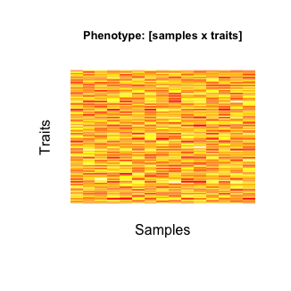

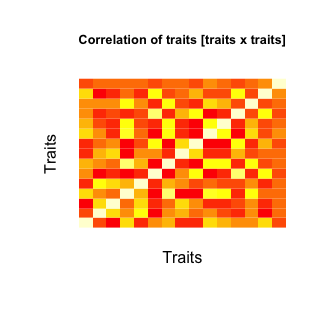

```r
### show 'image' of phenotype and correlation between phenotypic traits
image(t(phenotype$phenoComponents$Y), main="Phenotype: [samples x traits]", axes=FALSE, cex.main=0.8)
mtext(side = 1, text = "Samples", line = 1)
mtext(side = 2, text = "Traits", line = 1)
image(cor(phenotype$phenoComponents$Y), main="Correlation of traits [traits x traits]", axes=FALSE, cex.main=0.8)
mtext(side = 1, text = "Traits", line = 1)
mtext(side = 2, text = "Traits", line = 1)
```

The final phenotype and all its components can be saved via `savePheno`. `savePheno` simply takes the output of `runSimulation` or `createPheno` and saves every component found in there; if genotypes were simulated and a kinhsip estimated thereof, they will also be saved. The user needs to have writing permission to the specified genotype and phenotype directories. Optionally, sample sizes for phenotype and sample subsets of the $P$ and $N$ can be provided to save not only the full dataset, but also randomly drawn subsets thereof (useful for simulations demonstrating effects of sample size in for instance power studies or reproducibility of phenotype transformations). The code below saves the genotypes/phenotypes into the subdirectory “2017_04_04_simulation” of the directories ~/tmp/genotypes and ~/tmp/phenotypes. If the user has writing permissions and the directories do not exist yet, they will be created. In addition to the full set, phenotype and genotype subsets for $N={50,70}$ and $P={5,10}$ are saved.

```r
savePheno(phenotype, directoryGeno="~/tmp/genotypes",  directoryPheno="~/tmp/phenotypes", outstring="2017_04_04_simulation",
          sample_subset_vec = c(50, 70), pheno_subset_vec = c(5, 10), verbose=FALSE)
```

# Command line use

PhenotypeSimulator can also be run from the command line via `Rscript -e 'simulatePhenotypes()' --vanilla --default-packages=R.utils,PhenotypeSimulator,optparse --...` with `--...` being the user supplied simulation paramaters. `Rscript -e 'simulatePhenotypes()'` takes the same arguments as `runSimulation` and `savePheno`: first, it simulates the specified phenotype components and then saves them into to specified directories. To generate the same phenotypes as described above via the command line-interface, run the following code from your command line:

```bash
Rscript --vanilla --default-packages=R.utils,PhenotypeSimulator,optparse \
        -e 'simulatePhenotypes()'
        --NrSamples=100 --NrPhenotypes=15 \
        --tNrSNP=10000 --cNrSNP=30 \
        --SNPfrequencies=0.05,0.1,0.3,0.4 \
        --genVar=0.4 --h2s=0.025 --phi=0.6 --delta=0.3 --gamma=1 \
        --pcorr=0.8 \
        --NrFixedEffects=4 --NrConfounders=1,2,1,2 \
        --pSpecificConfounders=0,1,1,0.5 \
        --distConfounders=bin,cat_norm,cat_unif,norm \
        --probConfounders=0.2 \
        --catConfounders=0,3,4,0 \
        --directoryGeno=~/tmp/genotypes \
        --directoryPheno=~/tmp/phenotypes \
        --subdirectory=2017_04_04_simulation \
        --sampleSubset=50,70 \
        --phenoSubset=5,10 \
        --normalise \
        --verbose
```

# Phenotype component functions

## 1. fixed genetic effects:

Fixed genetic effects are simulated as the matrix product of an [N x NrCausalSNPs] genotype matrix and [NrSNP x P] effect size matrix. The genotype matrix can either be drawn from i) a simulated genotype matrix or ii) causal SNPs can be randomly drawn and read from existing genotype files. In the latter case, genotypes are expected to be stored in a [SNPs x N] format, with separate files for each chromosome. The user can either specify which chromosomes to sample the SNPs from or simply provide the total number of chromosomes to sample from. For the simulation of genotypes, the user can specify the `NrSNP`s to simulate and a vectore of allele frequencies `frequencies`. These allele frequencies are uniformly sampled and bi-allelic SNPs are simulated, with the sampled allele frequency acting as the probability in a binomial distribution with 2 trials.

```r
## a) Draw cuasal SNPs from a simulated genotype matrix
# simulate 10,000 bi-allelic SNP genotypes for 100 samples with randomly drawn allele frequencies of 0.05, 0.1, 0.3 and 0.4.
genotypes <- simulateGenotypes(N = 100, NrSNP = 10000, frequencies = c(0.05, 0.1, 0.3,0.4), verbose = FALSE)

# draw 10 causal SNPs from the genotype matrix (use non-standardised allele codes i.e. (0,1,2))
causalSNPs <- getCausalSNPs(NrCausalSNPs = 10, genotypes = genotypes, standardise = FALSE)
```

```r
## b) draw 10 causal SNPs from external genotype files: sample 10 SNPs from chromsome 22
# use one of the sample genotype files provided in the extdata/genotypes folder
genotypeFile <- system.file("extdata/genotypes/", "related_nopopstructure_chr22.csv", package = "PhenotypeSimulator")
genoFilePrefix <- gsub("chr.*", "", genotypeFile)
genoFileSuffix <- ".csv"

causalSNPsFromFile <- getCausalSNPs(NrCausalSNPs = 10, chr = 22, genoFilePrefix = genoFilePrefix, genoFileSuffix = genoFileSuffix,  standardise = FALSE, genoFileDelimiter = ",", verbose=FALSE)
```

```
#> Causal chromosomes: 22
```

```r
# create genetic fixed effects with 20% of SNPs having a specific effect, affecting 40% of all simulated traits
fixedGenetic <- geneticFixedEffects(X_causal = causalSNPs, N = 100, P = 20, pSpecificGenetic = 0.2, pTraitSpecificGenetic = 0.4)
```

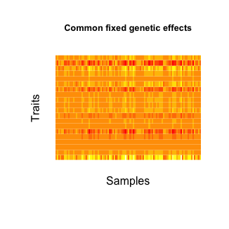

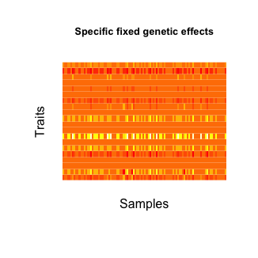

## 2. background genetic effects:

Background genetic effects are simulated via `geneticBgEffects` as two random genetic effects (common and specific) based on the kinship estimates of the (simulated) samples. The common effect is the same across all traits whereas the specific one affects each trait independently. This structure is achieved by combining three matrix components for each of the effects: : i) the kinship matrix $K$ [N x N] which is treated as the sample-design matrix (the genetic profile of the samples), ii) an effect-size matrix $B$ [N x P] with $vec(B)$ drawn from a normal distribution and iii) the trait design matrix $A$ [P x P]. For the specific effect, $A$ is a diagonal matrix with normally distributed values. $A$ of the common effect is a matrix of row rank one, with normally distributed entries in row 1 and zeros elsewhere. The three matrices are multiplied to obtain the desired final effect matrix $E$: $E = KBA$. As for the genetic fixed effects, the kinship can either be estimated from simulated genotypes or read in from file.

```r
## a) Estimate kinship from simulated genotypes
kinship <- getKinship(genotypes$X_sd, norm=TRUE, verbose = FALSE)

## b) Read kinship from external kinship file
kinshipFile <- system.file("extdata/kinship/", "kinship_related_nopopstructure.csv", package = "PhenotypeSimulator")
kinshipFromFile <- getKinship(kinshipfile = kinshipFile, norm=FALSE, verbose = FALSE)

genBg <- geneticBgEffects(kinship = kinship, N = 100, P = 15)
```

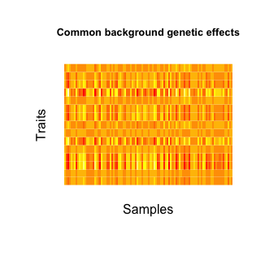

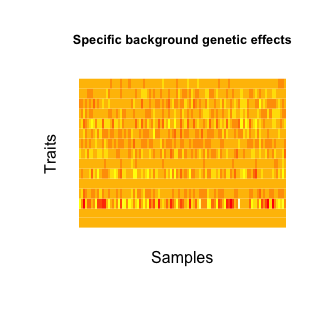